# QTM 150 Final Presentation

Nick Huberty, Alex Nuckols, William Chung, Caroline Ball

2025-12-09

## Introduction To Our Scenario

- Vmmmm Vmmmm, you get a Twitter notification, a zombie apocalypse has just been announced.
- Luck! A genie has gifted you a car with unlimited gas in the US - sans Hawaii and Alaska.
- Bad Luck!, you can drive it just once.
- Where do you go? This is what we set out to discover in our R project.

# How we picked candidate counties

- These counties are our bare bone counties
  - Enough farm land
  - Not too many people
  - Probable to find ammunition

# Beginning with Farming

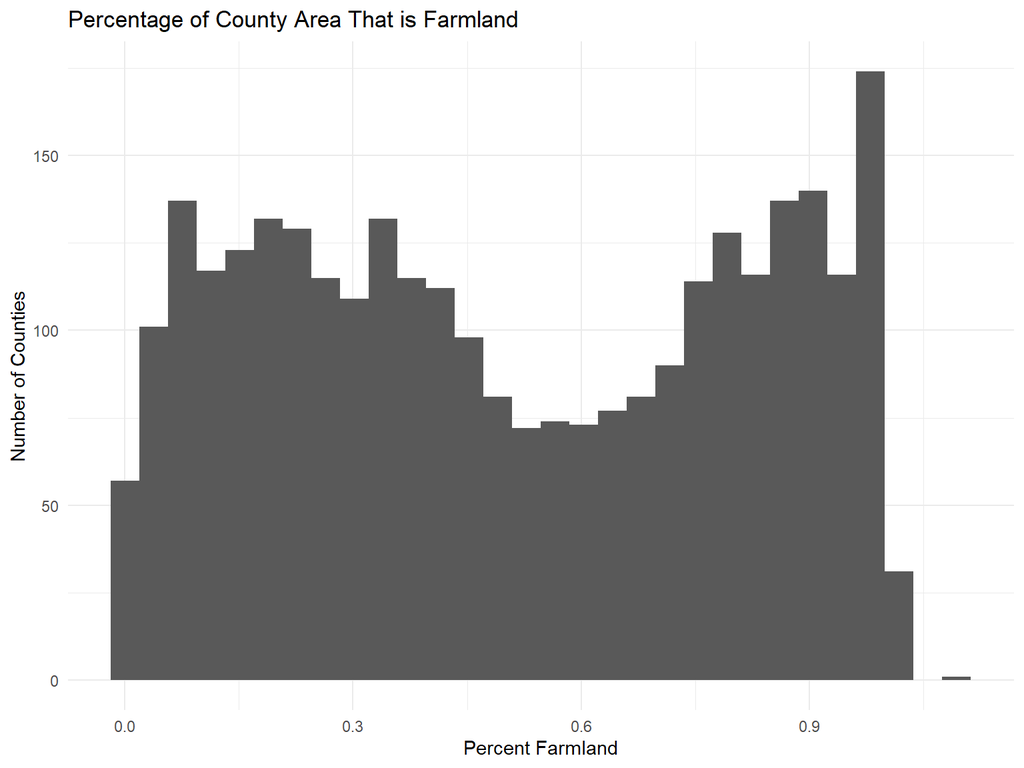

- This histogram shows us the number of counties with corresponding amounts of farm land

# Moving on to Population Density

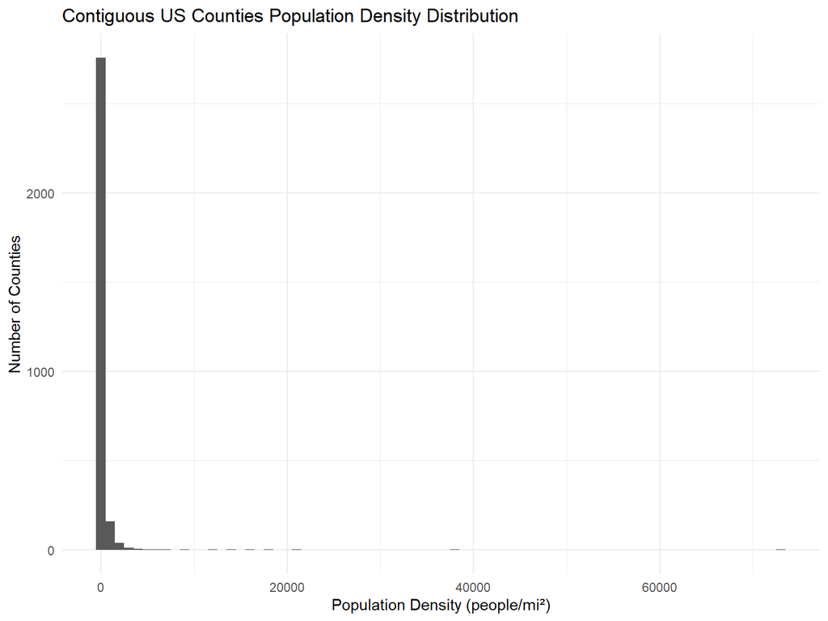

- This histogram shows us the counties with their corresponding population densities
- It was decided that population density <100 per mile^2 was a good parameter as it encapsulates most counties

# Combining These

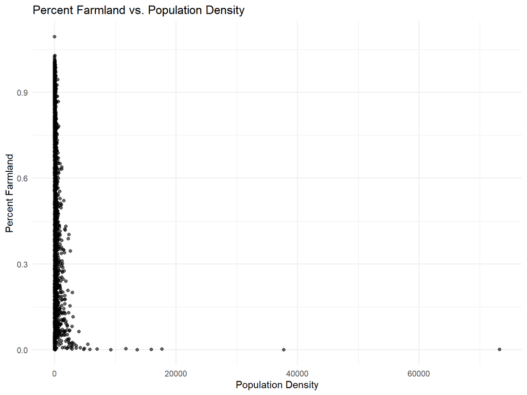

- Given the individual distributions, as well as the scatter plot, we decided threshold values of <100 people/mi^2 for population density, and >60% farmland would be ideal ranges that would give a broad range of candidate counties

# Scatter plot using these thresholds

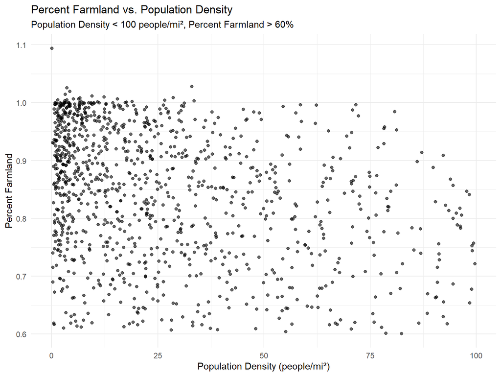

- This scatter plot shows us the candidate counties following our parameters
  - >60% farmland
  - <100 people/mile square
- From here we can add our third most important variable to surviving a zombie apocalypse

# Adding Guns

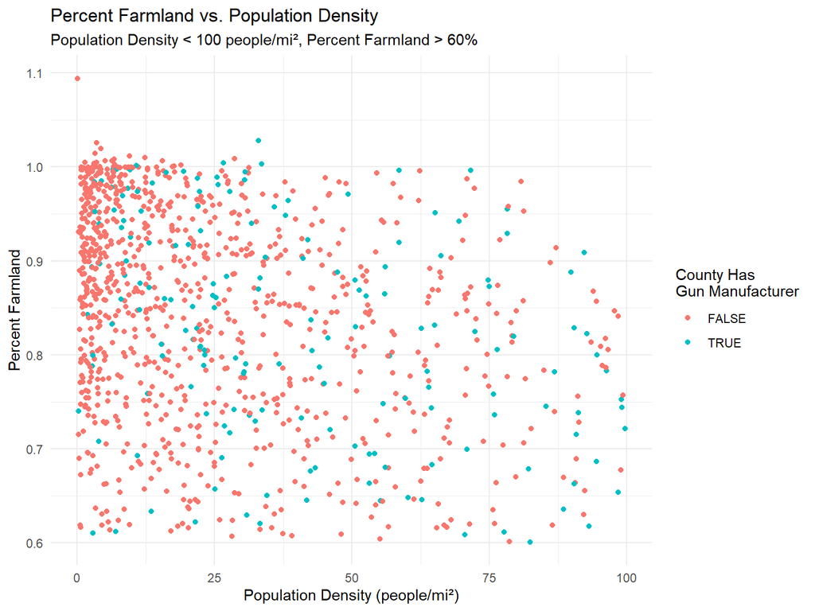

- Of our candidates, we take out counties without a gun manufacturer as counties without one would most likely have less ammunition to defend against the zombies
- This leaves us with a bare bones list of candidate counties

# Comparing Candidate Counties

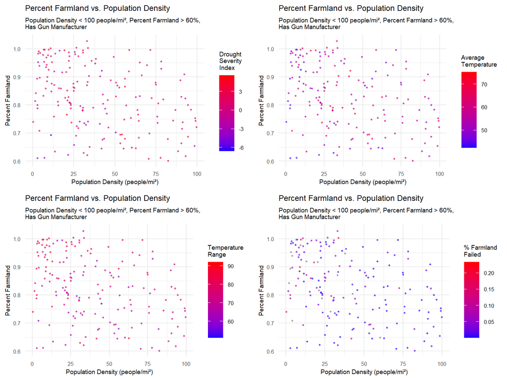

- You can use Notebook Output to see these graphs much more clearly
- Different variables were compared to the list of candidate counties, allowing, visually, the best counties to jump out more easily

# Zombie Index Parameters

- Density plots of candidate counties were used in order find thresholds for certain values
  - Drought severity
  - Average Temperature
  - Temperature Variance
  - Percent Farmland Failed
- These ranges were then used when creating the Zombie index, giving us our list of counties to go to during a zombie apocalypse

# Drought Severity Index Threshold

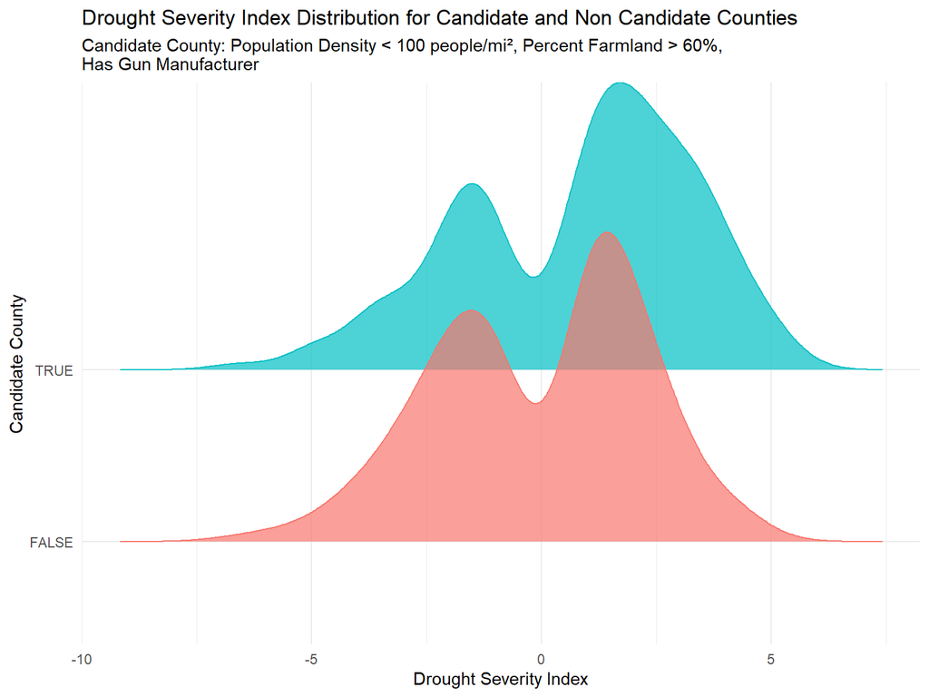

- Our drought severity parameter threshold ranged between 0 to 3, as average to slightly wet would most likely yield the most crops
- in terms of living as well. Dry climates and lack of water may become health issues later on.

# Average Temperature Threshold

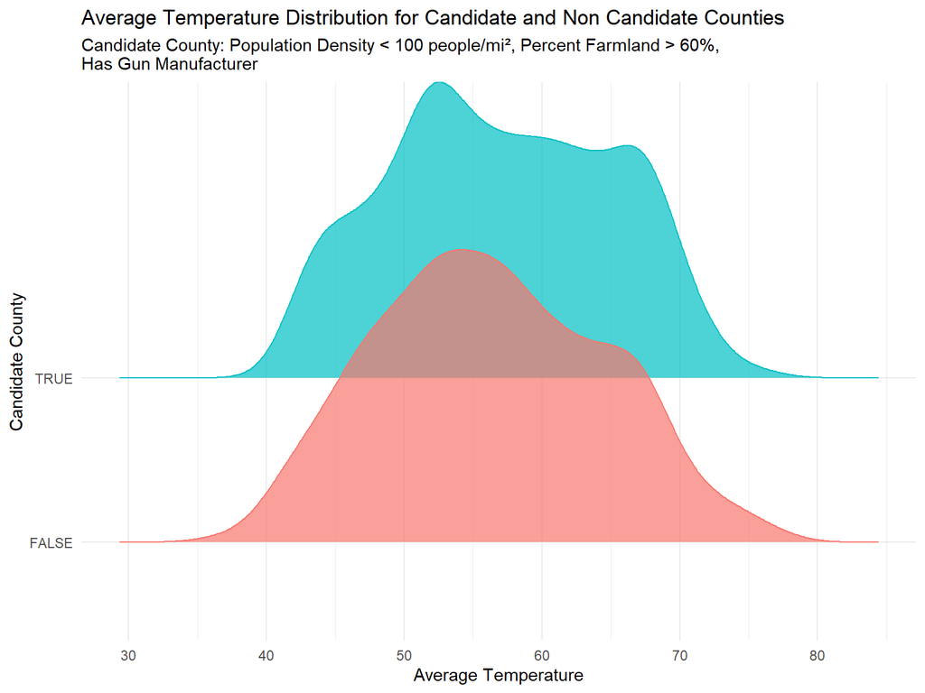

# Temperature Variation Threshold

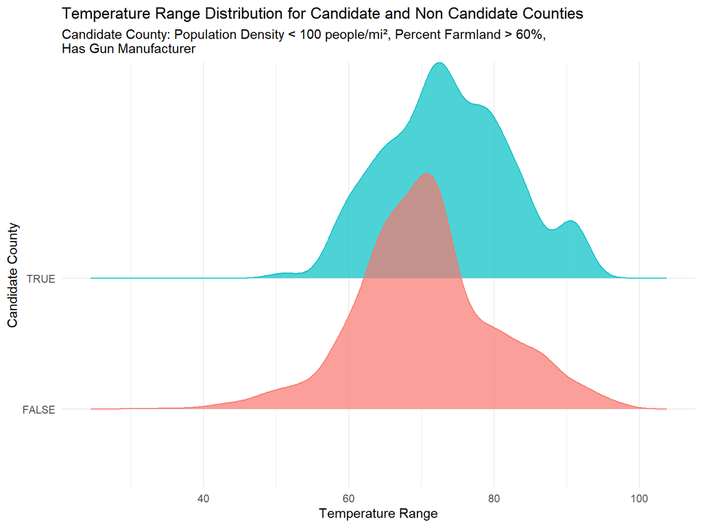

- Temperature range threshold was less than 75 degrees throughout the year, contains most candidate counties.

# Percent Farmland Failed Threshold

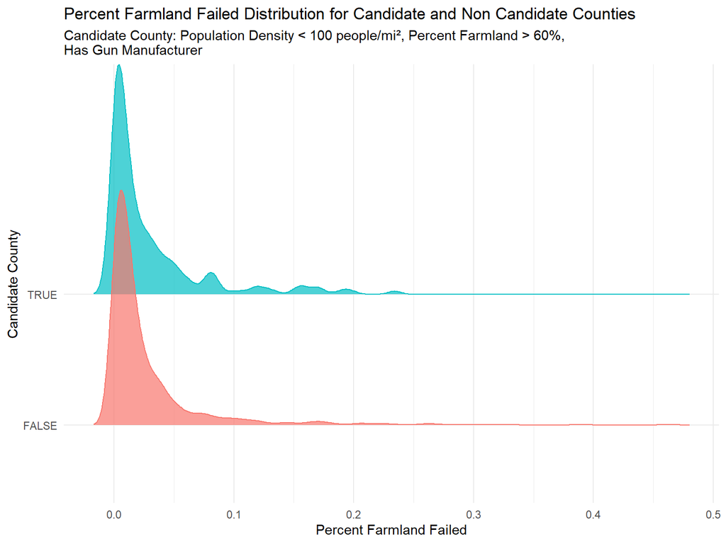

- Percent farmland failed below 0.1, or 10%, contains most candidate counties.
- We reason that 90% farmland success was enough for reliable food production

# Zombie Index

- Zombie Index was calculated based on ideal ranges for parameters. Lower index is a more ideal county.

# Sensitivity to Parameters

- To display how the zombie index varies based on parameters, plots show the sensitivity of the index value to each parameter.

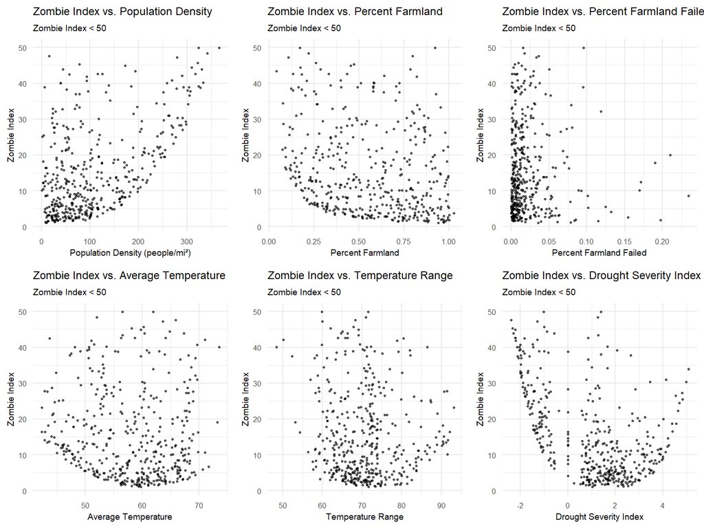

# Maps of Important Statistics

- Here are a few examples of variable maps for our variables. For the sake of brevity, we only include drought severity and precipitation here. In the next slide, we show the effect of all variables taken together.

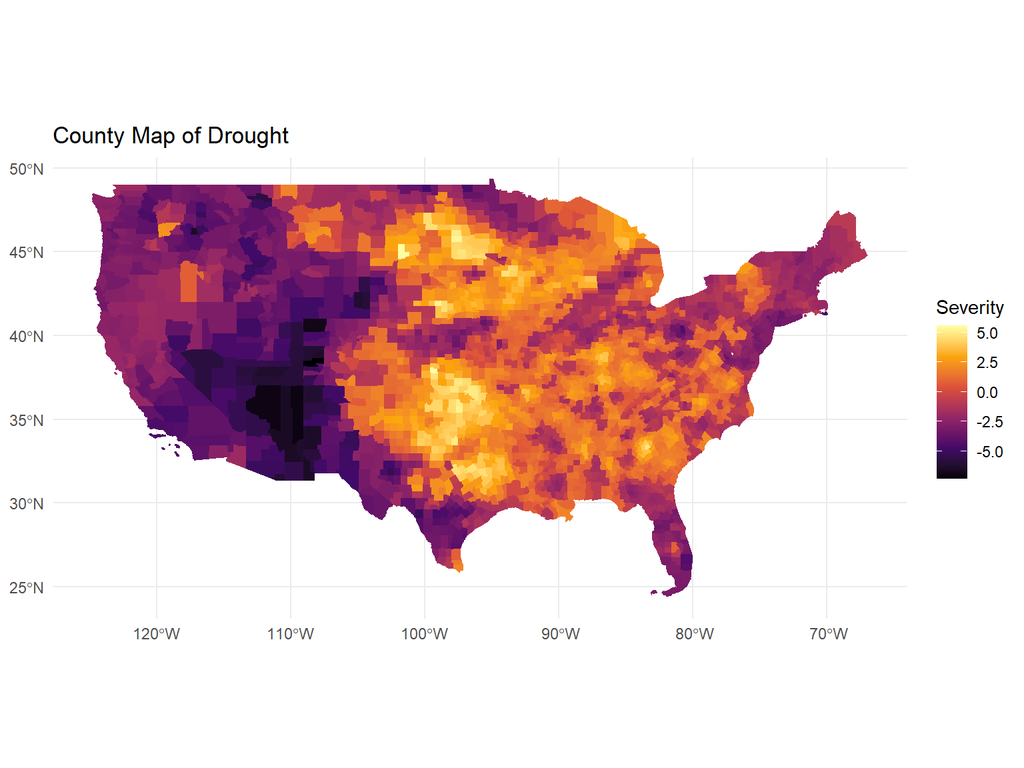

# Maps of Important Statistics

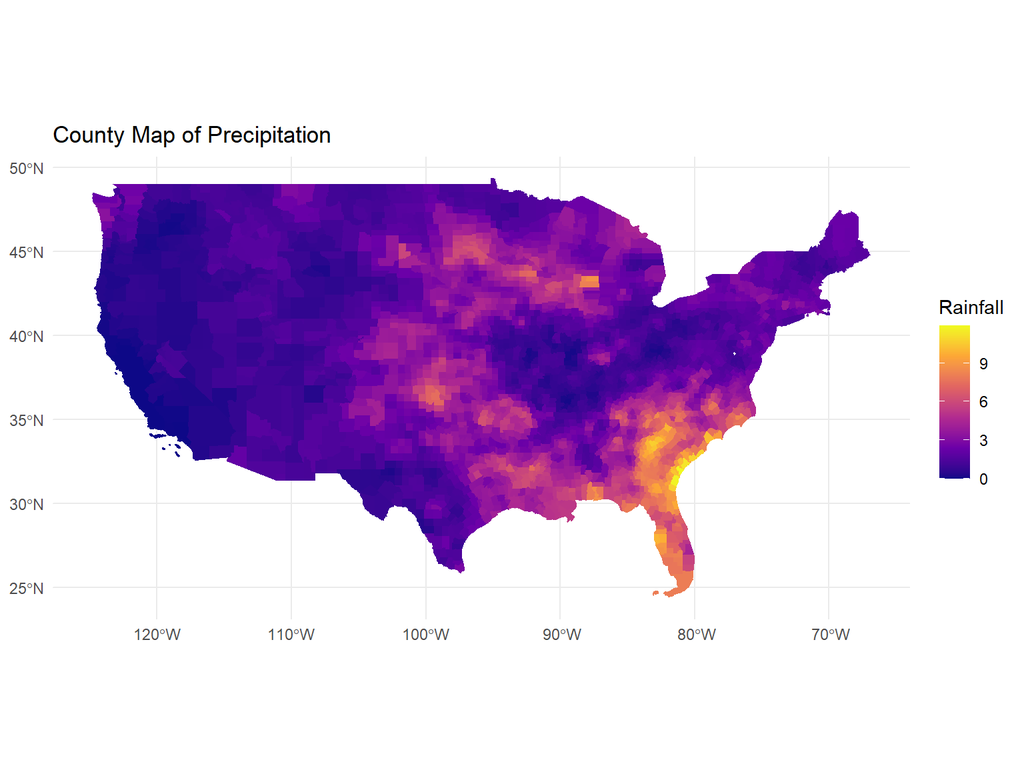

# Map of the MOST Important Statistic!

- This display demonstrates the areas near you that would be best for surviving zombies based on all our variables.
- DON’T go to Monroe County, Florida and get out of New York City if you’re from there.
- Head for Bailey County in Texas, Parmer County in Texas, Castro County in Texas, Neosho County in Kansas, and Lawrence County in Arkansas.
- Go go go go go go go go go go go go go

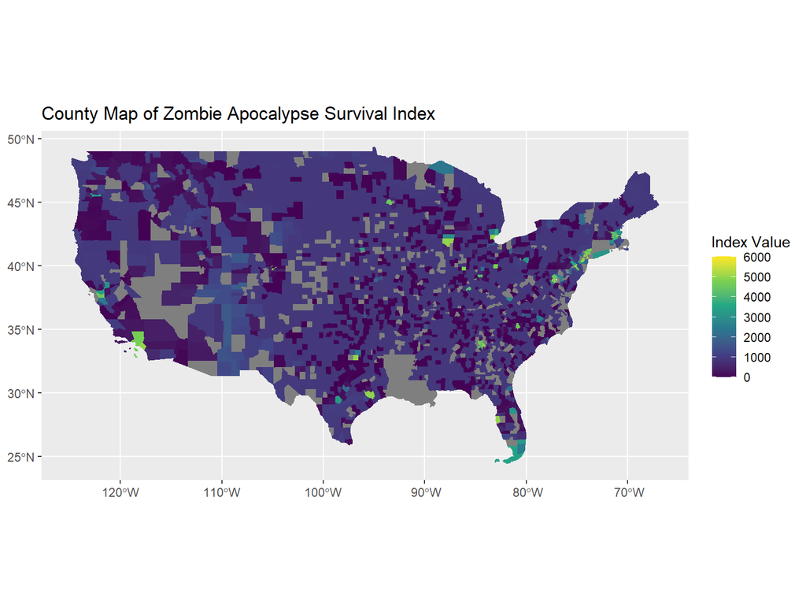